# Are people from different countries happy for different things? Why exactly are they happy for?

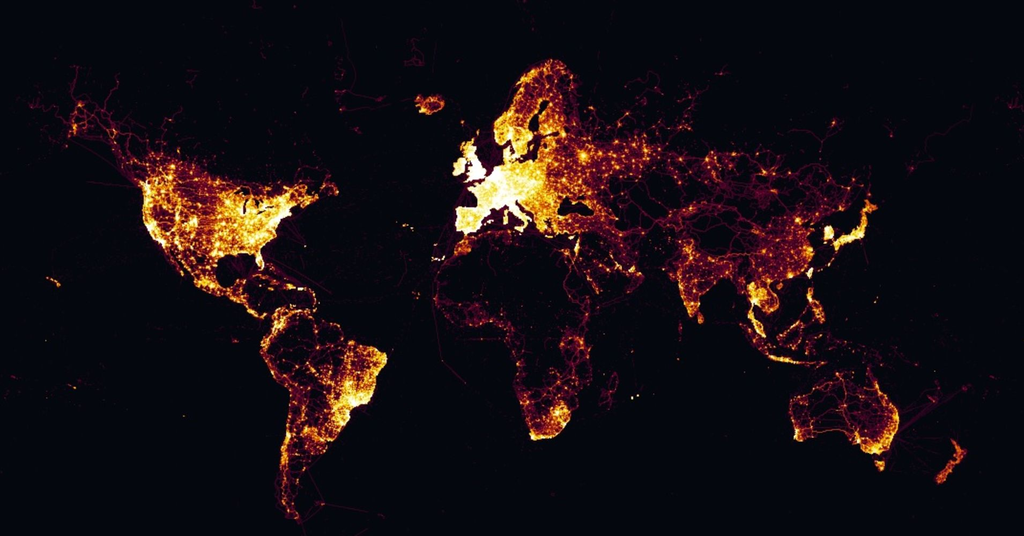

### Introduction

HappyDB is a corpus of 100,000 crowd-sourced happy moments, more details of the information could be found on the website https://arxiv.org/abs/1801.07746 and https://github.com/rit-public/HappyDB. In this project, we use a version of processed data ‘processed_moments.csv’ by file ‘Text_Processing.Rmd’ as well as file ‘demographic.csv’ which contains demographic information of the observations, it could be found on the website https://raw.githubusercontent.com/rit-public/HappyDB/master/happydb/data/demographic.csv. Based on the data sets, we aim to explore the data using visualized graphs and study the answers to the question, “What makes people happy?” via more advanced text mining tools such as sentiment analysis, topic model. We hope it would be a good start for people who are interested in this topic.

### Load required libaries and Merge text data with demographic information

First, we load required packages for analysis and merge the processed text data with demographic data, several rows of the merged data are shown as below:

```r
library(tidyverse)
library(tidytext)
library(DT)
library(scales)
library(gridExtra)
library(wordcloud)
library(tidyr)
library(ngram)
library(stringr)
library(broom)
library(rworldmap)
library(topicmodels)
hm_data <- read_csv("../output/processed_moments.csv")
urlfile<-'https://raw.githubusercontent.com/rit-public/HappyDB/master/happydb/data/demographic.csv'
demo_data <- read_csv(urlfile)
hm_data <- hm_data %>%
  inner_join(demo_data, by = "wid") %>%
  select(wid,
         cleaned_hm,
         gender,
         marital,
         parenthood,
         reflection_period,
         age,
         country,
         ground_truth_category,
         text) %>%
  mutate(count = sapply(hm_data$text, wordcount)) %>%
  filter(gender %in% c("m", "f")) %>%
  filter(marital %in% c("single", "married")) %>%
  filter(parenthood %in% c("n", "y")) %>%
  filter(reflection_period %in% c("24h", "3m")) %>%
  mutate(reflection_period = fct_recode(reflection_period,
                                        months_3 = "3m", hours_24 = "24h"))
head(hm_data)
```

```
## # A tibble: 6 x 11
##     wid cleaned_hm gender marital parenthood reflection_peri~ age   country
##   <int> <chr>      <chr>  <chr>   <chr>      <fct>            <chr> <chr>
## 1  2053 I went on~ m      single  n          hours_24         35    USA
## 2     2 I was hap~ m      married y          hours_24         29.0  IND
## 3  1936 I went to~ f      married y          hours_24         30    USA
## 4   206 We had a ~ f      married n          hours_24         28    DNK
## 5    45 I meditat~ m      single  n          hours_24         23    IND
## 6   195 I made a ~ m      single  n          hours_24         30    USA
## # ... with 3 more variables: ground_truth_category <chr>, text <chr>,
## #   count <int>
```

### Distribution of word count

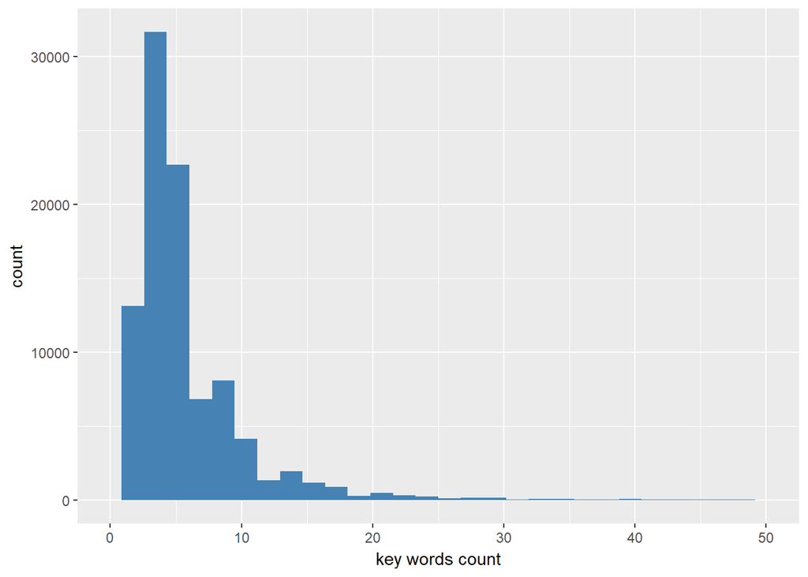

```r
p <- ggplot(hm_data, aes(count)) + geom_histogram(bins = 30, fill = "steelblue") + xlim(0,50) + xlab("key words count")
p
```

### Word cloud

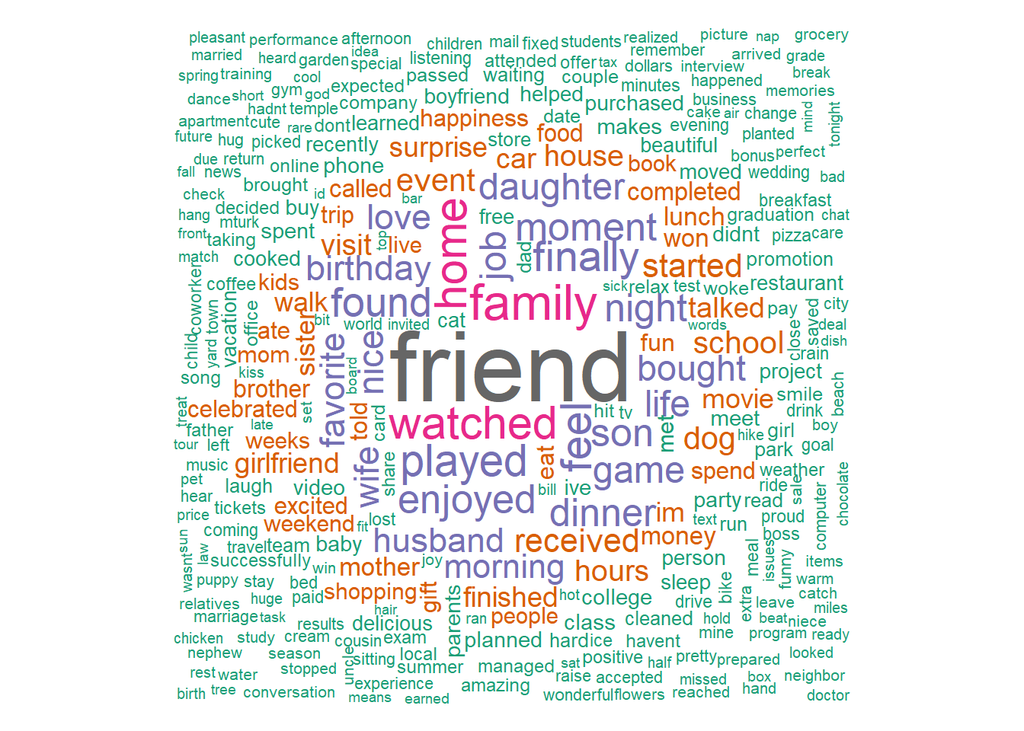

```r
bag_of_words <-  hm_data %>%
 unnest_tokens(word, text)
tb <- table(bag_of_words$word)
d <- data.frame(word = names(tb),freq=as.numeric(tb))
d <- d[order(d$freq, decreasing = TRUE), ]
d <- d[d$freq > 50,]
d <- d[! d$word %in% c('day',  'today',  'one', 'two', 'time', 'last', 'first','ago', 'now', 'month', 'week', 'day', 'yesterday', 'year',  'still', 'since', 'something'), ]
row.names(d) <- 1:nrow(d)
set.seed(2018)
wordcloud(words = d$word, freq = d$freq, min.freq = 1,
          random.order=FALSE,  max.words = 500,
          colors=brewer.pal(8, "Dark2"))
```

We use the word cloud to show the structure of the happy moments of people to see which words are mostly occured, to do the task, we use key words with frequency more than 50 so that words like “aaa”, “zzz” are not shown, also, we drop not useful words such as ‘day’, ‘today’, ‘one’ and etc, and we show maximum 500 words in the word cloud avoiding too many words. The word cloud illustrates that the most words are ‘friend’, ‘family’, ‘home’, ‘birthday’, ‘job’ and etc. So it means friend, family, birthday and working appear to cause people happy mostly. The details of top 20 such words could be found in the following histogram.

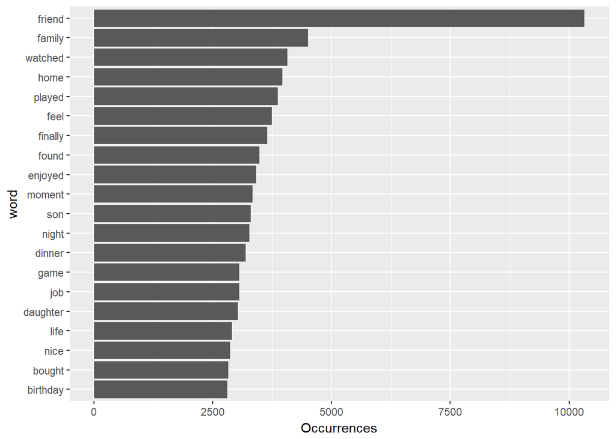

```r
p <- bag_of_words %>% filter(!word %in% c('day',  'today',  'one', 'two', 'time', 'last', 'first','ago', 'now', 'month', 'week', 'day', 'yesterday', 'year',  'still', 'since', 'something')) %>%  count(word, sort = TRUE) %>%
  head(20) %>%   mutate(word = reorder(word, n)) %>%   ggplot(aes(word, n)) +  geom_bar(stat = "identity") +  ylab("Occurrences") +   coord_flip()
p
```

In this graph, more information could be found that, people are happy might be due to their son and daughter, good dinner, play game and etc.

### Comparisions between groups

#### male vs. female

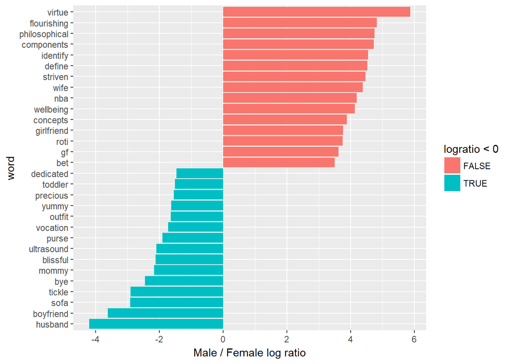

```r
p <- bag_of_words %>% filter(word %in% d$word) %>% count(word, gender) %>%  filter(sum(n) >= 5) %>%
  spread(gender, n, fill = 0) %>%  ungroup() %>%    mutate(logratio = log2((m +1) / (f+1))) %>%
  arrange(desc(logratio)) %>%   group_by(logratio > 0) %>%  top_n(15, abs(logratio)) %>%  ungroup() %>%
  mutate(word = reorder(word, logratio)) %>%   ggplot(aes(word, logratio, fill = logratio < 0)) +
  geom_bar(stat = "identity") +  coord_flip() +  ylab("Male / Female log ratio")
p
```

The words most different from causes happy for male and male are that male are mostly often happy due to nba, girlfriend, bet while female mostly often happy due to yummy, boyfriend, vocation.

#### single vs. married

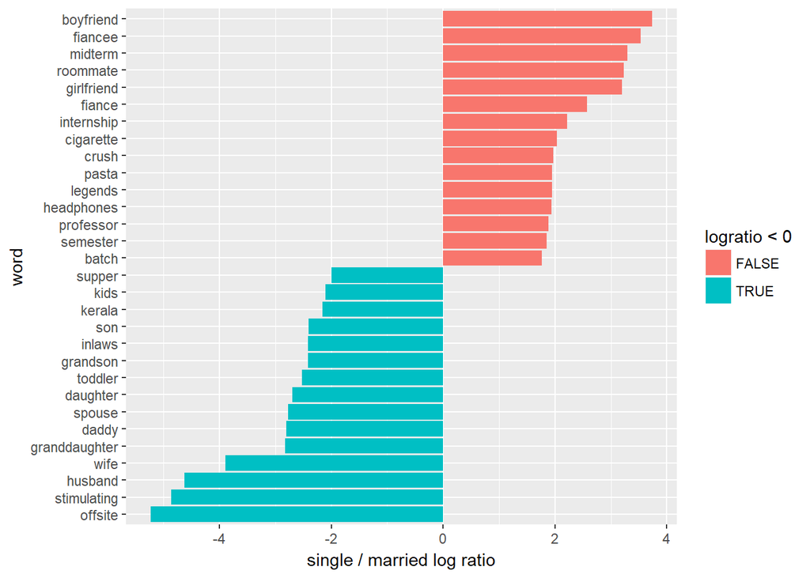

```r
p <- bag_of_words %>% filter(word %in% d$word) %>% count(word, marital) %>%  filter(sum(n) >= 5) %>%
  spread(marital, n, fill = 0) %>%  ungroup() %>%    mutate(logratio = log2((single +1) / (married+1))) %>%
  arrange(desc(logratio)) %>%   group_by(logratio > 0) %>%  top_n(15, abs(logratio)) %>%  ungroup() %>%
  mutate(word = reorder(word, logratio)) %>%   ggplot(aes(word, logratio, fill = logratio < 0)) +
  geom_bar(stat = "identity") +  coord_flip() +  ylab("single / married log ratio")
p
```

The words most different from causes happy for single and married are that single people are mostly often happy due to boyfriend or girlfriend(they are not married ye) and roommate as well as cigarette, but the married people mostly often happy due to their kids, the difference is obvious.

#### young vs. old

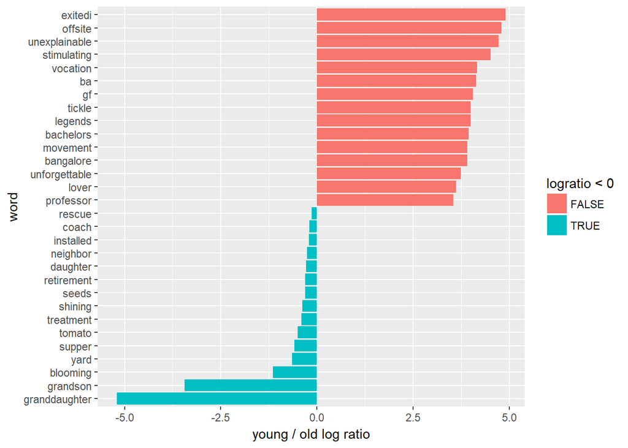

```r
p <- bag_of_words %>% filter(word %in% d$word)  %>% mutate(agecat = factor(ifelse(as.numeric(age) < 35, "young","old"))) %>% filter(!is.na(agecat))%>% count(word, agecat)  %>% filter(sum(n) >= 5)  %>%  spread(agecat, n, fill = 0) %>%  ungroup() %>%    mutate(logratio = log2((young +1) / (old+1))) %>%  arrange(desc(logratio)) %>%   group_by(logratio > 0) %>%  top_n(15, abs(logratio)) %>%  ungroup() %>%  mutate(word = reorder(word, logratio)) %>%   ggplot(aes(word, logratio, fill = logratio < 0)) +
  geom_bar(stat = "identity") +  coord_flip() +  ylab("young / old log ratio")
p
```

The words most different from causes happy for young and old are that young people are mostly often happy due to vocation that old people mostly often happy due to their neighbor, retirement, yard and their grandson, granddaughter.

[figure not shown]

### Sentiment analysis

```r
word_sentiment <- bag_of_words %>%
  inner_join(get_sentiments("bing")) %>%
  count(country,  sentiment) %>%
  spread(sentiment, n, fill = 0) %>%
  mutate(sentiment = positive - negative) %>% select(country, sentiment)
word_sentiment$sentiment <-  scale(word_sentiment$sentiment )
sPDF <- joinCountryData2Map( word_sentiment
,joinCode = "ISO3"
,nameJoinColumn = "country")
```

```
## 92 codes from your data successfully matched countries in the map
## 2 codes from your data failed to match with a country code in the map
## 151 codes from the map weren't represented in your data
```

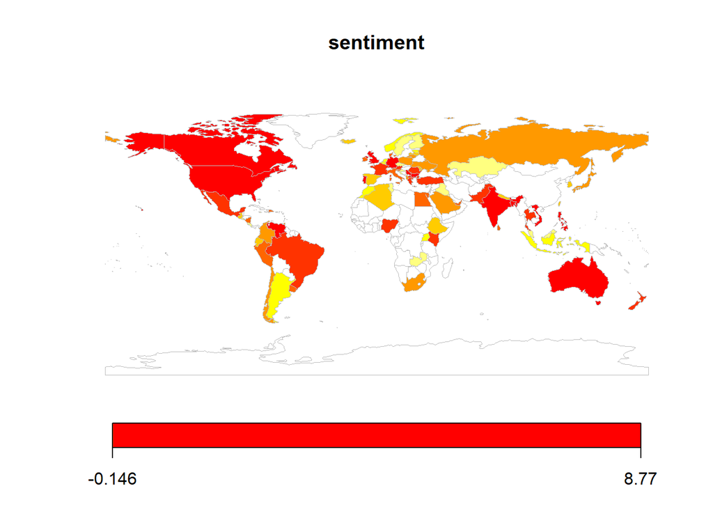

```r
mapCountryData(sPDF
,nameColumnToPlot='sentiment')
```

### topic model

At last, we use LDA topic model to explore the data, for this project, we want to find topics grouped by countries, we set 3 topics, the topics and top terms are:

```r
word_counts <- bag_of_words %>% filter(word %in% d$word) %>%
  anti_join(stop_words) %>%
  count(country, word, sort = TRUE) %>%
  ungroup()

dtm <- word_counts %>%
  cast_dtm(country, word, n)

lda <- LDA(dtm, k = 3, control = list(seed = 2018))
topics <- tidy(lda, matrix = "beta")
topics
```

```
## # A tibble: 4,593 x 3
##    topic term       beta
##    <int> <chr>     <dbl>
##  1     1 friend  0.0255
##  2     2 friend  0.00255
##  3     3 friend  0.0365
##  4     1 watched 0.00333
##  5     2 watched 0.00775
##  6     3 watched 0.0124
##  7     1 played  0.00411
##  8     2 played  0.00647
##  9     3 played  0.0120
## 10     1 finally 0.00342
## # ... with 4,583 more rows
```

```r
top_terms <- topics %>%
  group_by(topic) %>%
  top_n(5, beta) %>%
  ungroup() %>%
  arrange(topic, -beta)

top_terms
```

```
## # A tibble: 15 x 3
##    topic term        beta
##    <int> <chr>      <dbl>
##  1     1 friend   0.0255
##  2     1 moment   0.0254
##  3     1 life     0.0181
##  4     1 family   0.0164
##  5     1 feel     0.0145
##  6     2 finally  0.0161
##  7     2 daughter 0.0136
##  8     2 favorite 0.0116
##  9     2 dog      0.0114
## 10     2 found    0.00993
## 11     3 friend   0.0365
## 12     3 night    0.0124
## 13     3 watched  0.0124
## 14     3 played   0.0120
## 15     3 job      0.0117
```

We can show it directly:

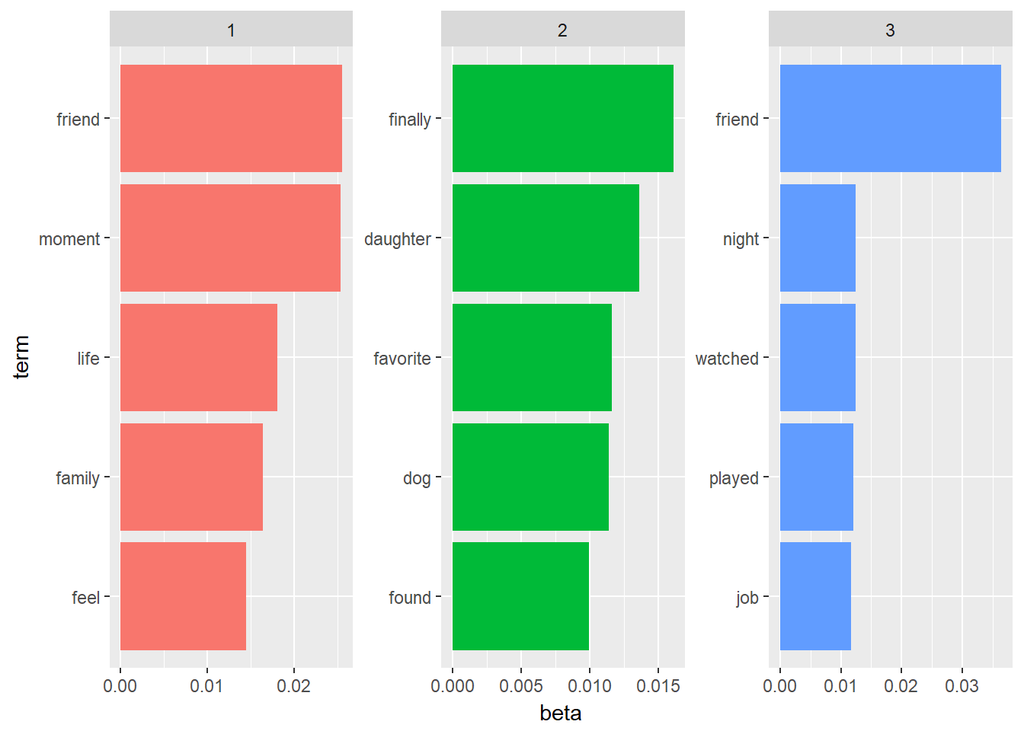

```r
top_terms %>%
  mutate(term = reorder(term, beta)) %>%
  ggplot(aes(term, beta, fill = factor(topic))) +
  geom_col(show.legend = FALSE) +
  facet_wrap(~ topic, scales = "free") +
  coord_flip()
```

## References

Sentiment/topic model : https://www.tidytextmining.com/twitter.html#comparing-word-usage

dataset info: https://arxiv.org/abs/1801.07746

picture1: https://www.cnbc.com/2018/01/28/global-heat-map-for-joggers-exposing-sensitive-us-military-information.html

picture2: https://www.happy-or-not.com/en/2017/02/happyornot-showcase-nb-iot-technology-mobile-world-congress/